# El tsunami: análisis y proyecciones

Daniel Gervini

15 de abril de 2021

Para el análisis usamos los [datos oficiales](http://datos.salud.gob.ar/dataset/covid-19-casos-registrados-en-la-republica-argentina) del Ministerio de Salud de la Nación, bajados el 14 de abril.

## Análisis: Capital y Provincia

Los siguientes gráficos muestran la evolución de casos y muertes diarias. La línea superpuesta es la que se obtiene a partir del modelo SIRD, que como se ve aproxima muy bien los datos observados (para detalles técnicos, ver [este posteo](https://dgervini.github.io/Coronavirus/Technical_details_T2C.html)). Claramente se ve una aceleración sin precedentes en el crecimiento de casos en las últimas semanas, tanto en Capital como en Provincia.

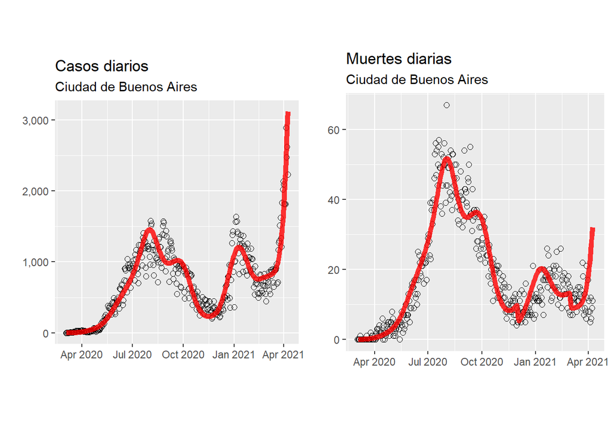

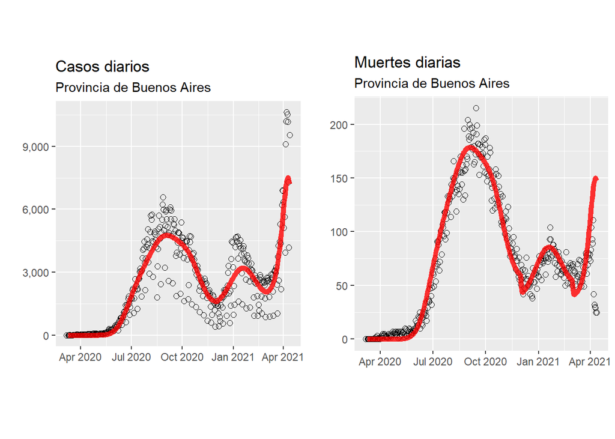

Hay que aclarar que como los datos se cargan con unos días de retraso, la cantidad de casos y, sobre todo, la cantidad de muertes, es inexacta en los últimos días de la serie (la aparente disminución en cantidad de muertes en Provincia en los últimos días se debe a este retraso).

La evolución de la epidemia está determinada por el número de reproducción $R_0$, que va variando a través del tiempo y se calcula a partir del modelo SIRD:

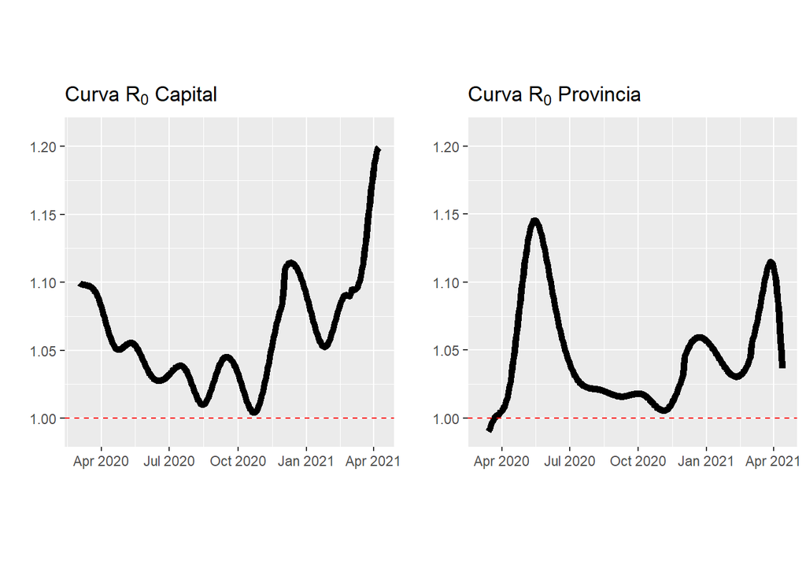

Como se ve, a partir del 1º de marzo de 2021 el $R_0$ ha variado entre 1,10 y 1,20 en Capital y entre 1,05 y 1,11 en Provincia. La aparente disminución del $R_0$ en Provincia en los últimos días probablemente se deba al retraso en la carga de datos que mencionábamos arriba. Por otro lado no es de extrañar que el $R_0$ sea menor en Provincia que en Capital, ya que estamos incuyendo el interior de la Provincia. Si tomáramos solamente los datos del conurbano, el $R_0$ estaría más cerca del de la Capital.

## Proyecciones

Tomando como base los $R_0$s recientes de 1,20 para Capital y 1,11 para Provincia, usando el modelo SIRD obtenemos las siguientes proyecciones de casos y muertes diarias para los próximos 60 días:

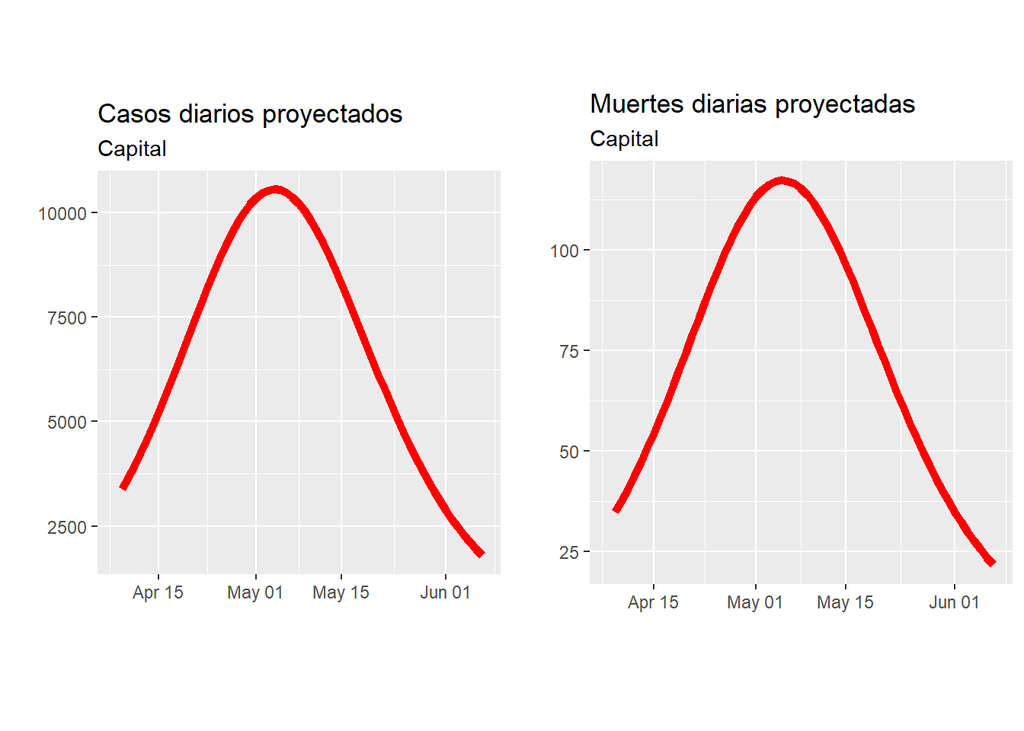

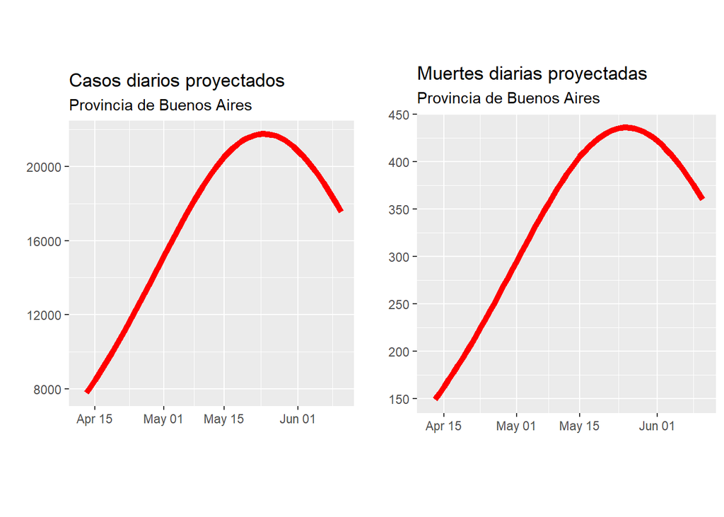

Según los gráficos de arriba, el pico de este “tsunami” en Capital llegaría a principios de mayo, con alrededor de 10.000 casos diarios y 120 muertes diarias. En total, en los próximos 60 días se agregarían 400.000 casos y 4.500 muertos, llegándose a un total acumulado de 680.000 casos y 11.800 muertos en Capital para mediados de junio.

En Provincia el pico llegaría recién para fines de mayo, con alrededor de 22.000 casos diarios y 450 muertes diarias. En total, en los próximos 60 días se agregarían 1.000.000 de casos y 20.000 muertos, llegándose a un total acumulado de 2.000.000 de casos y 51.000 muertos en Provincia para mediados de junio.

Parece improbable que las medidas anunciadas el 14 de abril “por quince días” tengan algún impacto en la evolución del “tsunami”. Además, según las proyecciones de arriba, el pico no va a llegar dentro de los próximos quince días ni en Capital ni en Provincia.

[Back to blog](https://sites.uwm.edu/gervini/coronavirus-blog/)